# Lab 2 Team Report

Isaac Tegeler, Nicholas Heger

9/12/2020

##### Searching for the Best Chocolates

1. How are the ratings distributed?

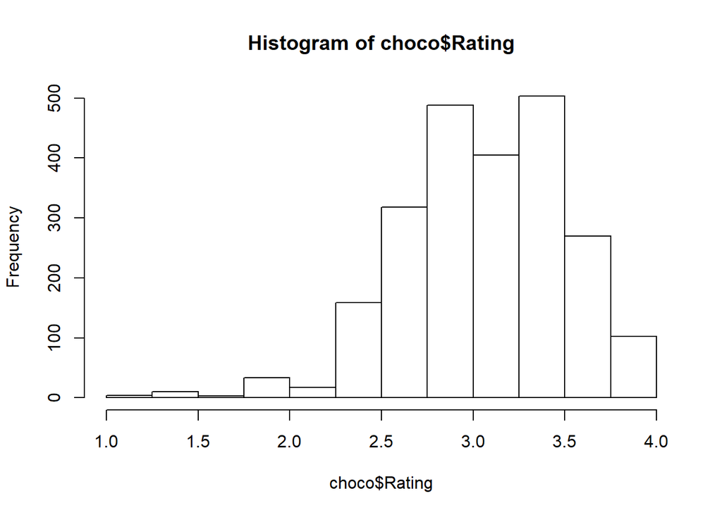

```r
hist(choco$Rating, breaks=seq(1.00, 4.00, .25))
```

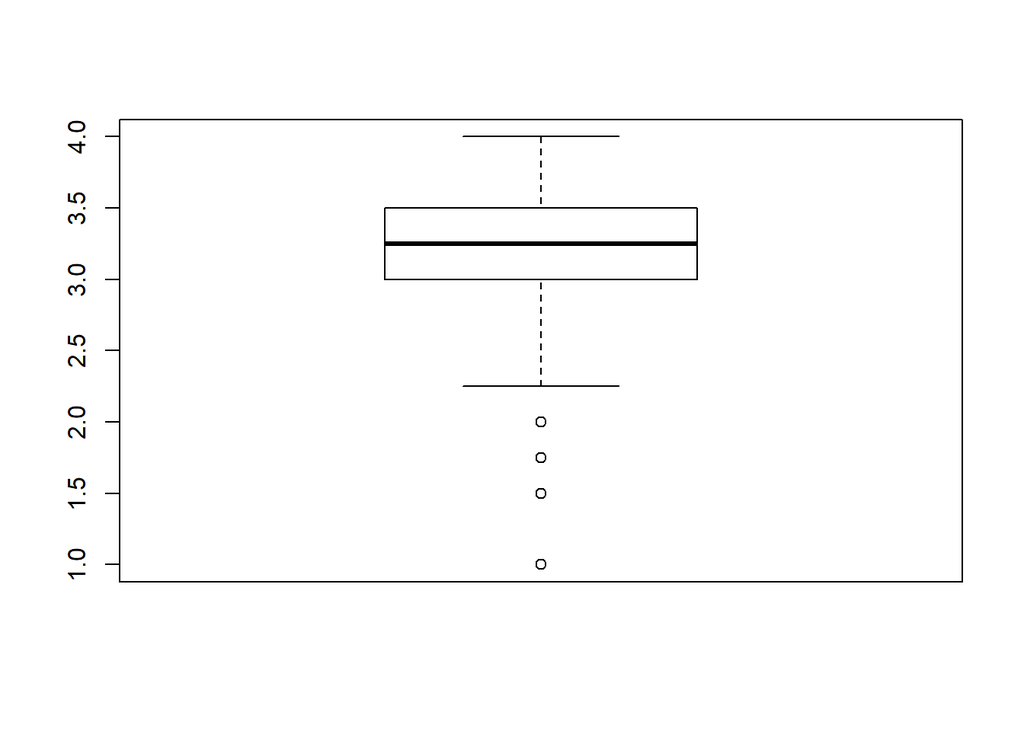

```r
boxplot(choco$Rating)
```

The ratings are skewed left, with most ratings above the halfway mark of 2.5. We can see from the boxplot that the median is around 3.3 and there are roughly 4 outliers all around or below a rating of 2.

2. How does the number of ratings depend on year?

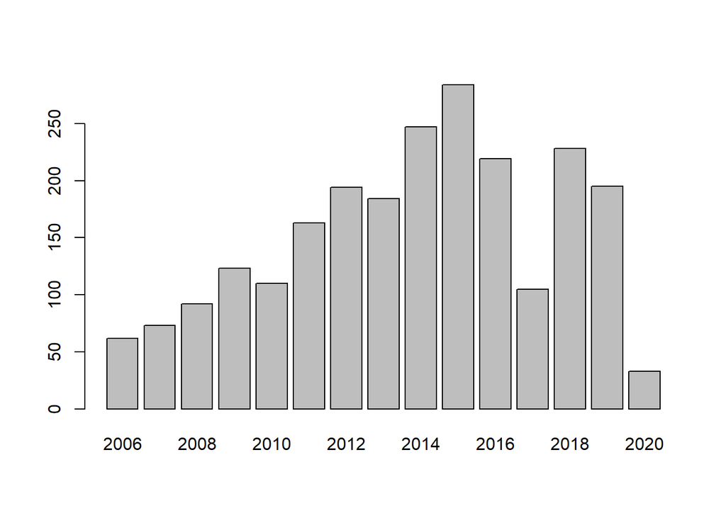

```r
barplot(table(choco$Date))
```

The number of ratings per year is generally increasing until 2015, and it generally decreases after that, with a notably few ratings in 2017.

3. Ratings vs Cocoa Percent

```r
cor(choco$Cocoa_Percent, choco$Rating, method = c("pearson"))
```

```
## [1] -0.1510178
```

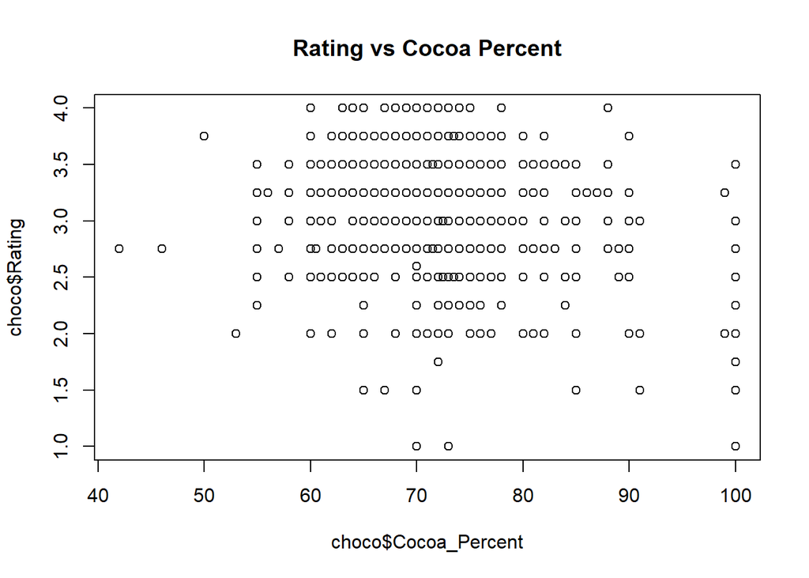

```r
plot(choco$Cocoa_Percent, choco$Rating, main='Rating vs Cocoa Percent')
```

The correlation coefficient between the percent cocoa and rating is very low indicating that there is not much correlation between the two variables. Looking at a graph of these two variables it is clear that there is very little correlation and no trend to the graph.

4. Favorable and non-favorable characteristics

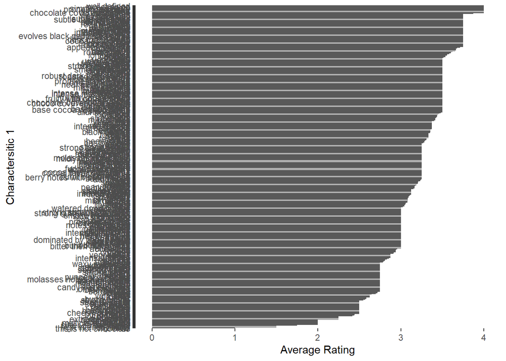

```r
#Get the average rating of a characteristic

ch1_mean <- setNames(aggregate(x = choco$Rating, by = list(choco$Characteristics1), FUN=mean), c("Characteristic 1", "Average Rating"))
ch1_ordered_mean <- ch1_mean[order(ch1_mean$`Average Rating`),]
ch1_ordered_mean$`Characteristic 1` <- factor(ch1_ordered_mean$`Characteristic 1`, levels = ch1_ordered_mean$`Characteristic 1`)

ggplot(ch1_ordered_mean, aes(x = `Characteristic 1`, y = `Average Rating`)) + geom_col() + coord_flip() + xlab("Charactersitic 1") + ylab("Average Rating")
```

You can see that there are too many characteristics to get a good view of which ones are the best and which ones or the worst, so we split them and just look at the top and bottom 10 ratings.

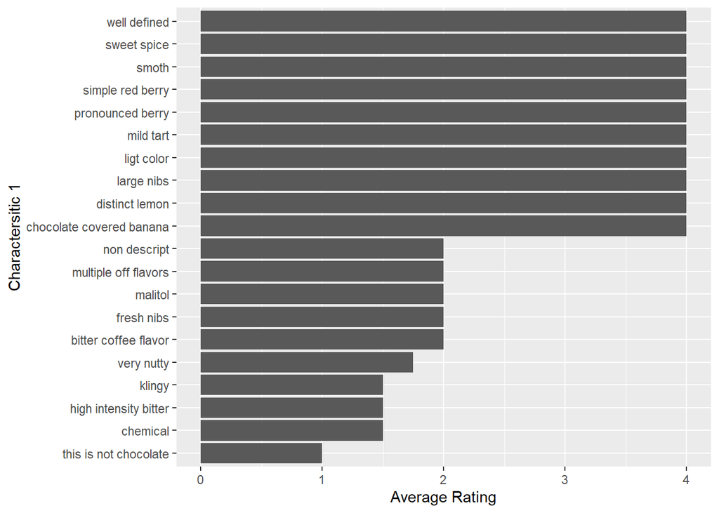

```r
extremes <- rbind(head(ch1_ordered_mean, 10), tail(ch1_ordered_mean, 10))

ggplot(extremes, aes(x = `Characteristic 1`, y = `Average Rating`)) + geom_col() + coord_flip() + xlab("Charactersitic 1") + ylab("Average Rating")
```

```r
#Best Rated Characteristics
print(head(extremes, 10))
```

```
##          Characteristic 1 Average Rating
## 414 this is not chocolate           1.00
## 68               chemical           1.50
## 169 high intensity bitter           1.50
## 195                klingy           1.50
## 432            very nutty           1.75
## 26   bitter coffee flavor           2.00
## 129            fresh nibs           2.00
## 210               malitol           2.00
## 256  multiple off flavors           2.00
## 261          non descript           2.00
```

```r
#Worst Rated Characteristics"
print(tail(extremes, 10))
```

```
##             Characteristic 1 Average Rating
## 72  chocolate covered banana              4
## 111           distinct lemon              4
## 197               large nibs              4
## 206               ligt color              4
## 239                mild tart              4
## 293         pronounced berry              4
## 335         simple red berry              4
## 359                    smoth              4
## 406              sweet spice              4
## 443             well defined              4
```

We listed out the characteristics in the bottom 10, followed by those in the top 10 according to the graph.

5. 2 Analyses  
   For our two analyses we plan to look at what companies make the best chocolate and what ingredients make the worst chocolate.

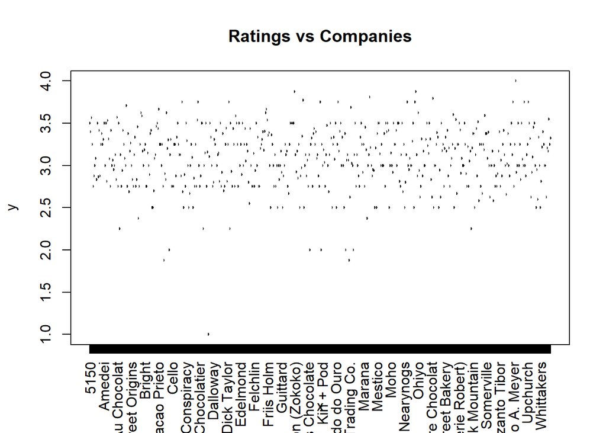

```r
ratingByCompany <- choco %>%
  group_by(Company) %>%
  summarise_at(vars(Rating), list(~mean(., na.rm=TRUE))) %>%
  arrange(-Rating)


plot(factor(ratingByCompany$Company), ratingByCompany$Rating, main="Ratings vs Companies", las=3)
```

```r
print(ratingByCompany)
```

```
## # A tibble: 541 x 2
##    Company                              Rating
##    <fct>                                 <dbl>
##  1 Tobago Estate (Pralus)                 4
##  2 Heirloom Cacao Preservation (Zokoko)   3.88
##  3 Ocelot                                 3.88
##  4 Matale                                 3.81
##  5 Patric                                 3.79
##  6 Idilio (Felchlin)                      3.78
##  7 Chocola'te                             3.75
##  8 Christopher Morel (Felchlin)           3.75
##  9 Dole (Guittard)                        3.75
## 10 Kerchner                               3.75
## # ... with 531 more rows
```

To look at which companies make the best chocolate, we can average the ratings each company received and look at which companies scored the highest. A plot of this isn’t particularly helpful since there are so many companies, and a graph of only some companies is no different than just displaying some of the top and bottom values, so a list of the top few companies by average rating, along with their average rating is shown above.

We can see that the top company is Tobago Estate (Pralus).

```r
ratingByIngredients <- choco %>%
  group_by(Ingredients) %>%
  summarise_at(vars(Rating), funs(mean(., na.rm=TRUE))) %>%
  arrange(Rating)
```

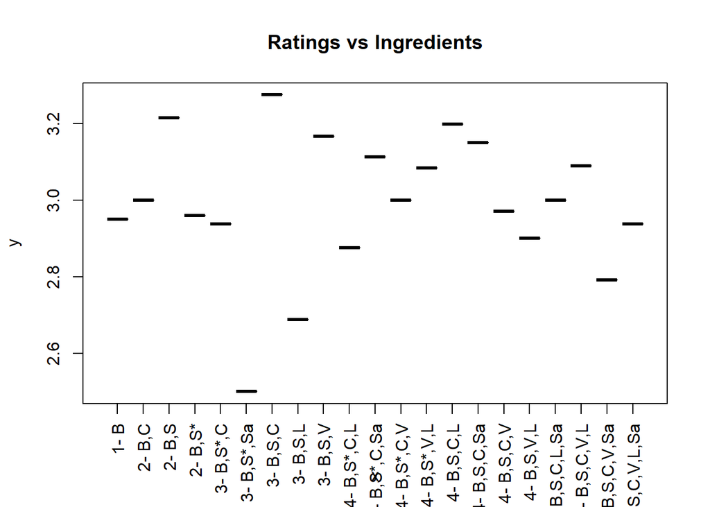

```r
plot(factor(ratingByIngredients$Ingredients), ratingByIngredients$Rating, main="Ratings vs Ingredients", las=3)
```

```r
print(ratingByIngredients)
```

```
## # A tibble: 22 x 2
##    Ingredients    Rating
##    <fct>           <dbl>
##  1 3- B,S*,Sa       2.5
##  2 3- B,S,L         2.69
##  3 5-B,S,C,V,Sa     2.79
##  4 <NA>             2.82
##  5 4- B,S*,C,L      2.88
##  6 4- B,S,V,L       2.9
##  7 3- B,S*,C        2.94
##  8 6-B,S,C,V,L,Sa   2.94
##  9 1- B             2.95
## 10 2- B,S*          2.96
## # ... with 12 more rows
```